# Project 2: Part 2

ST 590  
Summer 2022  
By Claudia Donahue and Collin Knezevich

We used the sqlite database called northwind.sqlite. This database originally comes from https://github.com/jpwhite3/northwind-SQLite3 but has been modified. We wrote up a report about the employees.

We reviewed the database and narrowed down a few things we wanted to investigate:

- each employee's revenue compared to the average revenue per employee
- employee use of discounts
- how employees sharing a region were faring
- which products employees were selling

First we connected to the database using the `sqlite3` package.

```python
import sqlite3

con = sqlite3.connect("northwind.sqlite")
```

Using `Pandas` dataframes, we started to investigate the contents of the database. First we grabbed a list of the tables present in the database. We also referenced a visualization of the database.

```python
# get a list of the tables in the db
import pandas as pd

tabs = pd.read_sql_query('SELECT name from sqlite_master where type= "table";', con)
tabs
```

|  | name |
| --- | --- |
| 0 | Categories |
| 1 | sqlite_sequence |
| 2 | CustomerCustomerDemo |
| 3 | CustomerDemographics |
| 4 | Customers |
| 5 | Employees |
| 6 | EmployeeTerritories |
| 7 | Order Details |
| 8 | Orders |
| 9 | Products |
| 10 | Regions |
| 11 | Shippers |
| 12 | Suppliers |
| 13 | Territories |

Then we took a look at the table listing our employees:

```python
employees = pd.read_sql_query('SELECT EmployeeID, LastName, FirstName, Title,\
                                Notes, ReportsTo FROM Employees;', con)
employees
```

|  | EmployeeID | LastName | FirstName | Title | Notes | ReportsTo |
| --- | --- | --- | --- | --- | --- | --- |
| 0 | 1 | Davolio | Nancy | Sales Representative | Education includes a BA in psychology from Col... | 2.0 |
| 1 | 2 | Fuller | Andrew | Vice President, Sales | Andrew received his BTS commercial in 1974 and... | NaN |
| 2 | 3 | Leverling | Janet | Sales Representative | Janet has a BS degree in chemistry from Boston... | 2.0 |
| 3 | 4 | Peacock | Margaret | Sales Representative | Margaret holds a BA in English literature from... | 2.0 |
| 4 | 5 | Buchanan | Steven | Sales Manager | Steven Buchanan graduated from St. Andrews Uni... | 2.0 |
| 5 | 6 | Suyama | Michael | Sales Representative | Michael is a graduate of Sussex University (MA... | 5.0 |
| 6 | 7 | King | Robert | Sales Representative | Robert King served in the Peace Corps and trav... | 5.0 |
| 7 | 8 | Callahan | Laura | Inside Sales Coordinator | Laura received a BA in psychology from the Uni... | 2.0 |
| 8 | 9 | Dodsworth | Anne | Sales Representative | Anne has a BA degree in English from St. Lawre... | 5.0 |

There are nine employees in the database. They include a Vice President of Sales, a Sales Manager, an Inside Sales Coordinator, and six Sales Representatives. They are located in either London or around Seattle.

Now we will gather the information available about sales. We start by reading in the Orders table. We were sure to include the columns telling us which employee handled the sale, the date of the sale, and the customer.

```python
orders = pd.read_sql_query('SELECT OrderID, CustomerID, EmployeeID, OrderDate, \
                            ShipVia, Freight FROM Orders;', con)

# Change ShipVia to a string data type
orders = orders.astype({"ShipVia": str}, errors='raise')

orders
```

|  | OrderID | CustomerID | EmployeeID | OrderDate | ShipVia | Freight |
| --- | --- | --- | --- | --- | --- | --- |
| 0 | 10248 | VINET | 5 | 1996-07-04 00:00:00.000 | 3 | 32.38 |
| 1 | 10249 | TOMSP | 6 | 1996-07-05 00:00:00.000 | 1 | 11.61 |
| 2 | 10250 | HANAR | 4 | 1996-07-08 00:00:00.000 | 2 | 65.83 |
| 3 | 10251 | VICTE | 3 | 1996-07-08 00:00:00.000 | 1 | 41.34 |
| 4 | 10252 | SUPRD | 4 | 1996-07-09 00:00:00.000 | 2 | 51.30 |
| ... | ... | ... | ... | ... | ... | ... |
| 825 | 11073 | PERIC | 2 | 1998-05-05 00:00:00.000 | 2 | 24.95 |
| 826 | 11074 | SIMOB | 7 | 1998-05-06 00:00:00.000 | 2 | 18.44 |
| 827 | 11075 | RICSU | 8 | 1998-05-06 00:00:00.000 | 2 | 6.19 |
| 828 | 11076 | BONAP | 4 | 1998-05-06 00:00:00.000 | 2 | 38.28 |
| 829 | 11077 | RATTC | 1 | 1998-05-06 00:00:00.000 | 2 | 8.53 |

830 rows × 6 columns

We can group by employee to get an idea of how many sales each employee made.

```python
# get a count of the number of orders (each orderID is a single order)
ordersPer = orders.groupby('EmployeeID').count().sort_values(by=['OrderID'], ascending=False)

# rename the column
ordersPer['countOrders'] = ordersPer['OrderID']

# save the object
ordersPer = ordersPer[['countOrders']]

ordersPer
```

| EmployeeID | countOrders |
| --- | --- |
| 4 | 156 |
| 3 | 127 |
| 1 | 123 |
| 8 | 104 |
| 2 | 96 |
| 7 | 72 |
| 6 | 67 |
| 9 | 43 |
| 5 | 42 |

We noticed there was no column annotating the value of each order, so we had to keep searching to find a way to compare sales. We thought that the total value of sales per employee would be more interesting than the quantity of sales. We found that price information in the Order Details table:

```python
orderDetails = pd.read_sql_query('SELECT * FROM "Order Details";', con)

# change ProductID to a string data type
orderDetails = orderDetails.astype({"ProductID": str}, errors='raise')

# rename the discount column
#orderDetails['DiscountPct'] = orderDetails['Discount']
orderDetails.rename(columns = {'Discount':'DiscountPct'}, inplace = True)

# calculate the revenue for each row
orderDetails['Revenue'] = ((orderDetails["UnitPrice"] * orderDetails["Quantity"]) * (1 - orderDetails["DiscountPct"])).round(2)

# calculate the dollar amount of discount given
orderDetails['DiscountAmt'] = ((orderDetails["UnitPrice"] * orderDetails["Quantity"]) * orderDetails["DiscountPct"]).round(2)

orderDetails
```

|  | OrderID | ProductID | UnitPrice | Quantity | DiscountPct | Revenue | DiscountAmt |
| --- | --- | --- | --- | --- | --- | --- | --- |
| 0 | 10248 | 11 | 14.00 | 12 | 0.00 | 168.0 | 0.0 |
| 1 | 10248 | 42 | 9.80 | 10 | 0.00 | 98.0 | 0.0 |
| 2 | 10248 | 72 | 34.80 | 5 | 0.00 | 174.0 | 0.0 |
| 3 | 10249 | 14 | 18.60 | 9 | 0.00 | 167.4 | 0.0 |
| 4 | 10249 | 51 | 42.40 | 40 | 0.00 | 1696.0 | 0.0 |
| ... | ... | ... | ... | ... | ... | ... | ... |
| 2150 | 11077 | 64 | 33.25 | 2 | 0.03 | 64.5 | 2.0 |
| 2151 | 11077 | 66 | 17.00 | 1 | 0.00 | 17.0 | 0.0 |
| 2152 | 11077 | 73 | 15.00 | 2 | 0.01 | 29.7 | 0.3 |
| 2153 | 11077 | 75 | 7.75 | 4 | 0.00 | 31.0 | 0.0 |
| 2154 | 11077 | 77 | 13.00 | 2 | 0.00 | 26.0 | 0.0 |

2155 rows × 7 columns

So we were able to merge the Orders table with the Order Details table and add up the total revenue per employee over the time period considered.

```python
# merge
orders1 = orders.merge(orderDetails, on=['OrderID'])

# change OrderID to a string data type
orders1 = orders1.astype({"OrderID": str}, errors='raise')

# Rank employees by total revenue
salesPer = orders1.groupby('EmployeeID').sum().sort_values(by=['Revenue'], ascending=False)
salesPer = salesPer.drop(columns = 'DiscountPct', axis = 1)
salesPer
```

| EmployeeID | Freight | UnitPrice | Quantity | Revenue | DiscountAmt |
| --- | --- | --- | --- | --- | --- |
| 4 | 37261.55 | 11187.29 | 9798 | 232890.87 | 17296.58 |
| 3 | 35783.62 | 8748.42 | 7852 | 202812.82 | 10238.47 |
| 1 | 28118.25 | 8732.44 | 7812 | 192107.59 | 10036.12 |
| 2 | 25924.53 | 6913.41 | 6055 | 166537.76 | 11211.50 |
| 8 | 23304.42 | 6239.25 | 5913 | 126862.27 | 6438.76 |
| 7 | 21667.67 | 4717.51 | 4654 | 124568.22 | 16727.77 |
| 9 | 10215.69 | 3380.20 | 2670 | 77308.06 | 5655.94 |
| 6 | 11123.09 | 3834.96 | 3527 | 73913.14 | 4284.97 |
| 5 | 13907.28 | 2747.43 | 3036 | 68792.29 | 6775.46 |

The range of revenue per employee was pretty big. From $68,792 (assuming we are working with US dollars) up to 232,891.

We also were interested in the revenue per sale for each employee, so we calculated it.

```python
# merge salesPer table with orders per employee
salesPer = salesPer.merge(ordersPer, on=['EmployeeID'])

# change OrderID to a string data type
salesPer = salesPer.astype({"countOrders": float}, errors='raise')

# create Revenue per Order column
salesPer["revPerOrder"] = (salesPer["Revenue"] / salesPer["countOrders"]).round(2)

salesPer
```

| EmployeeID | Freight | UnitPrice | Quantity | Revenue | DiscountAmt | countOrders | revPerOrder |
| --- | --- | --- | --- | --- | --- | --- | --- |
| 4 | 37261.55 | 11187.29 | 9798 | 232890.87 | 17296.58 | 156.0 | 1492.89 |
| 3 | 35783.62 | 8748.42 | 7852 | 202812.82 | 10238.47 | 127.0 | 1596.95 |
| 1 | 28118.25 | 8732.44 | 7812 | 192107.59 | 10036.12 | 123.0 | 1561.85 |
| 2 | 25924.53 | 6913.41 | 6055 | 166537.76 | 11211.50 | 96.0 | 1734.77 |
| 8 | 23304.42 | 6239.25 | 5913 | 126862.27 | 6438.76 | 104.0 | 1219.83 |
| 7 | 21667.67 | 4717.51 | 4654 | 124568.22 | 16727.77 | 72.0 | 1730.11 |
| 9 | 10215.69 | 3380.20 | 2670 | 77308.06 | 5655.94 | 43.0 | 1797.86 |
| 6 | 11123.09 | 3834.96 | 3527 | 73913.14 | 4284.97 | 67.0 | 1103.18 |
| 5 | 13907.28 | 2747.43 | 3036 | 68792.29 | 6775.46 | 42.0 | 1637.91 |

Here we see that Employee 4, who has the largest total revenue, actually is not leading in Revenue per Order.

We can visualize the Revenue generated by each employee, and the revenue per order for each employee with bar charts.

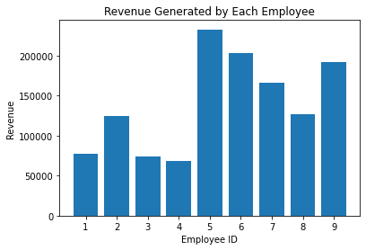

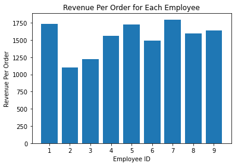

```python
from matplotlib import pyplot as plt
# creating bar plot for revenue
order = [5, 6, 9, 7, 8, 2, 1, 3, 4]
plt.bar(x = order, height = salesPer.Revenue)
plt.xlabel("Employee ID")
plt.ylabel("Revenue")
plt.title("Revenue Generated by Each Employee")
plt.xticks(order)
plt.show()
plt.close()

# creating bar plot for revenue per order
order = [6, 8, 4, 1, 3, 5, 7, 2, 9]
plt.bar(x = order, height = salesPer.revPerOrder)
plt.xlabel("Employee ID")
plt.ylabel("Revenue Per Order")
plt.title("Revenue Per Order for Each Employee")
plt.xticks(order)
plt.show()
plt.close()
```

Similarly, we can analyze how the employees have performed across years. In the orders table, we can note the timeframe of the sales was from mid 1996 to mid 1998. We will have to extract the year from the OrderDate variable, and group by year as well as EmployeeID.

```python
# find year, add to data frame
for i in range(0, len(orders)):
    dateString = str(orders.loc[i, "OrderDate"])
    yr = dateString[0:4]
    orders.loc[i, "Year"] = yr
```

```python
# find year, add to data frame
for i in range(0, len(orders)):
    dateString = str(orders.loc[i, "OrderDate"])
    yr = dateString[0:4]
    orders.loc[i, "Year"] = yr
```

```python
# count orders
ordersPerYear = orders.groupby(['EmployeeID', 'Year']).count()["OrderID"]
ordersPerYear = pd.DataFrame(ordersPerYear)
# rename column
ordersPerYear["countOrders"] = ordersPerYear["OrderID"]
ordersPerYear = ordersPerYear["countOrders"]
ordersPerYear = pd.DataFrame(ordersPerYear)
```

We can now add total revenue per year, and revenue per order by year for each employee.

```python
# getting total revenue by year per employee
orders2 = orders.merge(orderDetails, on = ["OrderID"])

salesPerYear = orders2.groupby(["EmployeeID", "Year"]).sum()
salesPerYear = salesPerYear.iloc[:, [1, 2, 3, 5, 6]]

# merge with order counts info
salesPerYear = salesPerYear.merge(ordersPerYear, on = ["EmployeeID", "Year"])

# calculate revenue per order
salesPerYear["revPerOrder"] = (salesPerYear["Revenue"]/salesPerYear["countOrders"]).round(2)
salesPerYear
```

| EmployeeID | Year | Freight | UnitPrice | Quantity | Revenue | DiscountAmt | countOrders | revPerOrder |
| --- | --- | --- | --- | --- | --- | --- | --- | --- |
| 1 | 1996 | 5578.78 | 1691.40 | 1620 | 35764.51 | 3024.49 | 26 | 1375.56 |
|  | 1997 | 16490.13 | 3957.08 | 3877 | 93148.10 | 4385.49 | 55 | 1693.60 |
|  | 1998 | 6049.34 | 3083.96 | 2315 | 63194.98 | 2626.14 | 42 | 1504.64 |
| 2 | 1996 | 2585.52 | 822.20 | 1085 | 21757.06 | 1077.64 | 16 | 1359.82 |
|  | 1997 | 13428.55 | 3195.24 | 2604 | 70444.14 | 4514.46 | 41 | 1718.15 |
|  | 1998 | 9910.46 | 2895.97 | 2366 | 74336.56 | 5619.40 | 39 | 1906.07 |
| 3 | 1996 | 2483.58 | 812.60 | 940 | 18223.96 | 1007.84 | 18 | 1012.44 |
|  | 1997 | 24108.09 | 4568.01 | 4436 | 108026.13 | 3762.47 | 71 | 1521.49 |
|  | 1998 | 9191.95 | 3367.81 | 2476 | 76562.73 | 5468.16 | 38 | 2014.81 |
| 4 | 1996 | 6968.06 | 2340.40 | 2212 | 49945.12 | 3169.68 | 31 | 1611.13 |
|  | 1997 | 21571.62 | 6074.42 | 5273 | 128809.81 | 10667.89 | 81 | 1590.24 |
|  | 1998 | 8721.87 | 2772.47 | 2313 | 54135.94 | 3459.01 | 44 | 1230.36 |
| 5 | 1996 | 4836.31 | 701.70 | 778 | 18383.92 | 3581.28 | 11 | 1671.27 |
|  | 1997 | 4003.83 | 1136.99 | 1471 | 30716.48 | 1878.57 | 18 | 1706.47 |
|  | 1998 | 5067.14 | 908.74 | 787 | 19691.89 | 1315.61 | 13 | 1514.76 |
| 6 | 1996 | 2431.01 | 778.30 | 963 | 16642.60 | 1088.50 | 15 | 1109.51 |
|  | 1997 | 6065.90 | 2148.73 | 1738 | 43126.38 | 2865.63 | 33 | 1306.86 |
|  | 1998 | 2626.18 | 907.93 | 826 | 14144.16 | 330.84 | 19 | 744.43 |
| 7 | 1996 | 1587.75 | 639.10 | 485 | 15232.16 | 2872.64 | 11 | 1384.74 |
|  | 1997 | 10138.15 | 2430.86 | 2292 | 60471.19 | 6217.95 | 36 | 1679.76 |
|  | 1998 | 9941.77 | 1647.55 | 1877 | 48864.87 | 7637.18 | 25 | 1954.59 |
| 8 | 1996 | 3313.44 | 1352.30 | 923 | 22240.12 | 921.28 | 19 | 1170.53 |
|  | 1997 | 8011.07 | 2683.46 | 2843 | 56032.61 | 3743.91 | 54 | 1037.64 |
|  | 1998 | 11979.91 | 2203.49 | 2147 | 48589.54 | 1773.57 | 31 | 1567.40 |
| 9 | 1996 | 2287.08 | 272.20 | 575 | 9894.52 | 1471.18 | 5 | 1978.90 |
|  | 1997 | 2974.73 | 1420.29 | 955 | 26310.39 | 3267.16 | 19 | 1384.76 |
|  | 1998 | 4953.88 | 1687.71 | 1140 | 41103.15 | 917.60 | 19 | 2163.32 |

Let's create a way to compare an employee's revenue per order for a certain year against the overall revenue per order for all employees. We will calculate the revenue per order for a given year, and subtract that from each employee's revenue per order for that year. (Thus, a positive value will indicate an employee had a better revenue per order than the overall revenue per order, and vice versa).

```python
# count orders
ordersPerYear2 = orders.groupby("Year").count()["OrderID"]
ordersPerYear2 = pd.DataFrame(ordersPerYear2)
# rename column
ordersPerYear2["countOrders"] = ordersPerYear2["OrderID"]
ordersPerYear2 = ordersPerYear2["countOrders"]
ordersPerYear2 = pd.DataFrame(ordersPerYear2)
```

```python
salesPerYear2 = orders2.groupby("Year").sum()
salesPerYear2 = salesPerYear2.iloc[:, 6]
salesPerYear2 = pd.DataFrame(salesPerYear2)
salesPerYear2 = salesPerYear2.merge(ordersPerYear2, on = ["Year"])

# calculating revenue per order
salesPerYear2["revPerOrder"] = (salesPerYear2["Revenue"]/salesPerYear2["countOrders"]).round(2)
salesPerYear2 = pd.DataFrame(salesPerYear2["revPerOrder"])
salesPerYear2
```

| Year | revPerOrder |
| --- | --- |
| 1996 | 1368.97 |
| 1997 | 1512.46 |
| 1998 | 1631.94 |

```python
import numpy as np

# adding yearly values to dataframe
s1996 = 1368.97
s1997 = 1512.46
s1998 = 1631.94
salesPerYear["revPerOverall"] = np.tile([s1996, s1997, s1998], 9)

# calculating difference
salesPerYear["revDiff"] = salesPerYear["revPerOrder"] - salesPerYear["revPerOverall"]
salesPerYear
```

| EmployeeID | Year | Freight | UnitPrice | Quantity | Revenue | DiscountAmt | countOrders | revPerOrder | revPerOverall | revDiff |
| --- | --- | --- | --- | --- | --- | --- | --- | --- | --- | --- |
| 1 | 1996 | 5578.78 | 1691.40 | 1620 | 35764.51 | 3024.49 | 26 | 1375.56 | 1368.97 | 6.59 |
|  | 1997 | 16490.13 | 3957.08 | 3877 | 93148.10 | 4385.49 | 55 | 1693.60 | 1512.46 | 181.14 |
|  | 1998 | 6049.34 | 3083.96 | 2315 | 63194.98 | 2626.14 | 42 | 1504.64 | 1631.94 | -127.30 |
| 2 | 1996 | 2585.52 | 822.20 | 1085 | 21757.06 | 1077.64 | 16 | 1359.82 | 1368.97 | -9.15 |
|  | 1997 | 13428.55 | 3195.24 | 2604 | 70444.14 | 4514.46 | 41 | 1718.15 | 1512.46 | 205.69 |
|  | 1998 | 9910.46 | 2895.97 | 2366 | 74336.56 | 5619.40 | 39 | 1906.07 | 1631.94 | 274.13 |
| 3 | 1996 | 2483.58 | 812.60 | 940 | 18223.96 | 1007.84 | 18 | 1012.44 | 1368.97 | -356.53 |
|  | 1997 | 24108.09 | 4568.01 | 4436 | 108026.13 | 3762.47 | 71 | 1521.49 | 1512.46 | 9.03 |
|  | 1998 | 9191.95 | 3367.81 | 2476 | 76562.73 | 5468.16 | 38 | 2014.81 | 1631.94 | 382.87 |
| 4 | 1996 | 6968.06 | 2340.40 | 2212 | 49945.12 | 3169.68 | 31 | 1611.13 | 1368.97 | 242.16 |
|  | 1997 | 21571.62 | 6074.42 | 5273 | 128809.81 | 10667.89 | 81 | 1590.24 | 1512.46 | 77.78 |
|  | 1998 | 8721.87 | 2772.47 | 2313 | 54135.94 | 3459.01 | 44 | 1230.36 | 1631.94 | -401.58 |
| 5 | 1996 | 4836.31 | 701.70 | 778 | 18383.92 | 3581.28 | 11 | 1671.27 | 1368.97 | 302.30 |
|  | 1997 | 4003.83 | 1136.99 | 1471 | 30716.48 | 1878.57 | 18 | 1706.47 | 1512.46 | 194.01 |
|  | 1998 | 5067.14 | 908.74 | 787 | 19691.89 | 1315.61 | 13 | 1514.76 | 1631.94 | -117.18 |
| 6 | 1996 | 2431.01 | 778.30 | 963 | 16642.60 | 1088.50 | 15 | 1109.51 | 1368.97 | -259.46 |
|  | 1997 | 6065.90 | 2148.73 | 1738 | 43126.38 | 2865.63 | 33 | 1306.86 | 1512.46 | -205.60 |
|  | 1998 | 2626.18 | 907.93 | 826 | 14144.16 | 330.84 | 19 | 744.43 | 1631.94 | -887.51 |
| 7 | 1996 | 1587.75 | 639.10 | 485 | 15232.16 | 2872.64 | 11 | 1384.74 | 1368.97 | 15.77 |
|  | 1997 | 10138.15 | 2430.86 | 2292 | 60471.19 | 6217.95 | 36 | 1679.76 | 1512.46 | 167.30 |
|  | 1998 | 9941.77 | 1647.55 | 1877 | 48864.87 | 7637.18 | 25 | 1954.59 | 1631.94 | 322.65 |
| 8 | 1996 | 3313.44 | 1352.30 | 923 | 22240.12 | 921.28 | 19 | 1170.53 | 1368.97 | -198.44 |
|  | 1997 | 8011.07 | 2683.46 | 2843 | 56032.61 | 3743.91 | 54 | 1037.64 | 1512.46 | -474.82 |
|  | 1998 | 11979.91 | 2203.49 | 2147 | 48589.54 | 1773.57 | 31 | 1567.40 | 1631.94 | -64.54 |
| 9 | 1996 | 2287.08 | 272.20 | 575 | 9894.52 | 1471.18 | 5 | 1978.90 | 1368.97 | 609.93 |
|  | 1997 | 2974.73 | 1420.29 | 955 | 26310.39 | 3267.16 | 19 | 1384.76 | 1512.46 | -127.70 |
|  | 1998 | 4953.88 | 1687.71 | 1140 | 41103.15 | 917.60 | 19 | 2163.32 | 1631.94 | 531.38 |

From these results, we can identify some employees that have underperformed every year, and some employees that have overperformed every year. Notably, employee 6 has underperformed every year, and had a sharp decrease in revenue per order in 1998. This represents a clear area of improvement for them.

We can visualize each employee's relative performance over time with line charts.

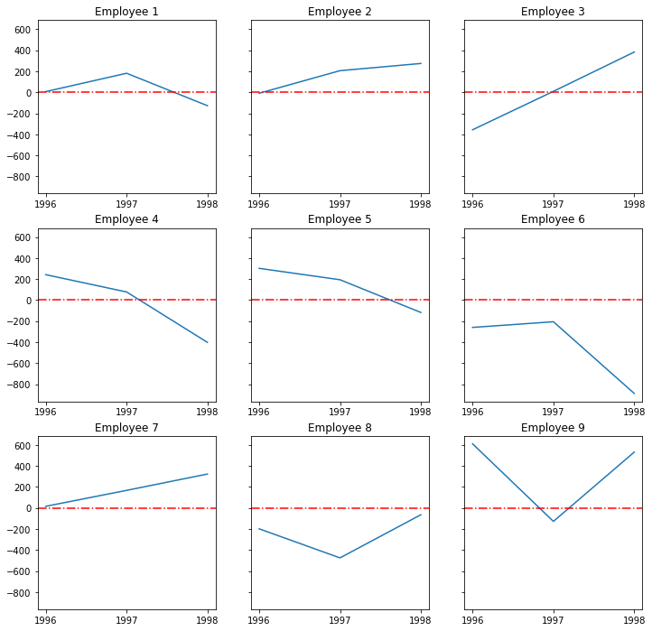

```python
# creating grid of line charts
fig, axs = plt.subplots(3, 3, sharey = True, figsize = (12, 12))

axs[0,0].plot(salesPerYear.loc[1, "revDiff"])
axs[0,0].set_title("Employee 1")

axs[0,1].plot(salesPerYear.loc[2, "revDiff"])
axs[0,1].set_title("Employee 2")

axs[0,2].plot(salesPerYear.loc[3, "revDiff"])
axs[0,2].set_title("Employee 3")

axs[1,0].plot(salesPerYear.loc[4, "revDiff"])
axs[1,0].set_title("Employee 4")

axs[1,1].plot(salesPerYear.loc[5, "revDiff"])
axs[1,1].set_title("Employee 5")

axs[1,2].plot(salesPerYear.loc[6, "revDiff"])
axs[1,2].set_title("Employee 6")

axs[2,0].plot(salesPerYear.loc[7, "revDiff"])
axs[2,0].set_title("Employee 7")

axs[2,1].plot(salesPerYear.loc[8, "revDiff"])
axs[2,1].set_title("Employee 8")

axs[2,2].plot(salesPerYear.loc[9, "revDiff"])
axs[2,2].set_title("Employee 9")

for ax in axs.flat:
    ax.axhline(y = 0, color = "red", linestyle = "dashdot")
```

This helps us visualize how each employee's performance is trending over time, and how their performance compares to overall performances. For instance, we can see that employees 3 and 7 have improved each year, while employees 4 and 5 have gotten worse each year.

Let's repeat this same exercise, but instead analyzing total revenue per employee per year. (Assume we expect sales revenue to be evenly distributed among the employees. So an employee's expected total sales revenue will be the total for that year divided by 9).

```python
totRevYear = orders2.groupby("Year").sum()["Revenue"]
totRevYear = pd.DataFrame(totRevYear)
totRevYear
```

| Year | Revenue |
| --- | --- |
| 1996 | 208083.97 |
| 1997 | 617085.23 |
| 1998 | 440623.82 |

```python
# adding yearly values to dataframe
r1996 = 208083.97/9
r1997 = 617085.23/9
r1998 = 440623.82/9
salesPerYear["exRev"] = np.tile([r1996, r1997, r1998], 9)
salesPerYear["exRev"] = salesPerYear["exRev"].round(2)

# calculating difference
salesPerYear["totRevDiff"] = salesPerYear["Revenue"] - salesPerYear["exRev"]
salesPerYear
```

| EmployeeID | Year | Freight | UnitPrice | Quantity | Revenue | DiscountAmt | countOrders | revPerOrder | revPerOverall | revDiff | exRev | totRevDiff |
| --- | --- | --- | --- | --- | --- | --- | --- | --- | --- | --- | --- | --- |
| 1 | 1996 | 5578.78 | 1691.40 | 1620 | 35764.51 | 3024.49 | 26 | 1375.56 | 1368.97 | 6.59 | 23120.44 | 12644.07 |
|  | 1997 | 16490.13 | 3957.08 | 3877 | 93148.10 | 4385.49 | 55 | 1693.60 | 1512.46 | 181.14 | 68565.03 | 24583.07 |
|  | 1998 | 6049.34 | 3083.96 | 2315 | 63194.98 | 2626.14 | 42 | 1504.64 | 1631.94 | -127.30 | 48958.20 | 14236.78 |
| 2 | 1996 | 2585.52 | 822.20 | 1085 | 21757.06 | 1077.64 | 16 | 1359.82 | 1368.97 | -9.15 | 23120.44 | -1363.38 |
|  | 1997 | 13428.55 | 3195.24 | 2604 | 70444.14 | 4514.46 | 41 | 1718.15 | 1512.46 | 205.69 | 68565.03 | 1879.11 |
|  | 1998 | 9910.46 | 2895.97 | 2366 | 74336.56 | 5619.40 | 39 | 1906.07 | 1631.94 | 274.13 | 48958.20 | 25378.36 |
| 3 | 1996 | 2483.58 | 812.60 | 940 | 18223.96 | 1007.84 | 18 | 1012.44 | 1368.97 | -356.53 | 23120.44 | -4896.48 |
|  | 1997 | 24108.09 | 4568.01 | 4436 | 108026.13 | 3762.47 | 71 | 1521.49 | 1512.46 | 9.03 | 68565.03 | 39461.10 |
|  | 1998 | 9191.95 | 3367.81 | 2476 | 76562.73 | 5468.16 | 38 | 2014.81 | 1631.94 | 382.87 | 48958.20 | 27604.53 |
| 4 | 1996 | 6968.06 | 2340.40 | 2212 | 49945.12 | 3169.68 | 31 | 1611.13 | 1368.97 | 242.16 | 23120.44 | 26824.68 |
|  | 1997 | 21571.62 | 6074.42 | 5273 | 128809.81 | 10667.89 | 81 | 1590.24 | 1512.46 | 77.78 | 68565.03 | 60244.78 |
|  | 1998 | 8721.87 | 2772.47 | 2313 | 54135.94 | 3459.01 | 44 | 1230.36 | 1631.94 | -401.58 | 48958.20 | 5177.74 |
| 5 | 1996 | 4836.31 | 701.70 | 778 | 18383.92 | 3581.28 | 11 | 1671.27 | 1368.97 | 302.30 | 23120.44 | -4736.52 |
|  | 1997 | 4003.83 | 1136.99 | 1471 | 30716.48 | 1878.57 | 18 | 1706.47 | 1512.46 | 194.01 | 68565.03 | -37848.55 |
|  | 1998 | 5067.14 | 908.74 | 787 | 19691.89 | 1315.61 | 13 | 1514.76 | 1631.94 | -117.18 | 48958.20 | -29266.31 |
| 6 | 1996 | 2431.01 | 778.30 | 963 | 16642.60 | 1088.50 | 15 | 1109.51 | 1368.97 | -259.46 | 23120.44 | -6477.84 |
|  | 1997 | 6065.90 | 2148.73 | 1738 | 43126.38 | 2865.63 | 33 | 1306.86 | 1512.46 | -205.60 | 68565.03 | -25438.65 |
|  | 1998 | 2626.18 | 907.93 | 826 | 14144.16 | 330.84 | 19 | 744.43 | 1631.94 | -887.51 | 48958.20 | -34814.04 |
| 7 | 1996 | 1587.75 | 639.10 | 485 | 15232.16 | 2872.64 | 11 | 1384.74 | 1368.97 | 15.77 | 23120.44 | -7888.28 |
|  | 1997 | 10138.15 | 2430.86 | 2292 | 60471.19 | 6217.95 | 36 | 1679.76 | 1512.46 | 167.30 | 68565.03 | -8093.84 |
|  | 1998 | 9941.77 | 1647.55 | 1877 | 48864.87 | 7637.18 | 25 | 1954.59 | 1631.94 | 322.65 | 48958.20 | -93.33 |
| 8 | 1996 | 3313.44 | 1352.30 | 923 | 22240.12 | 921.28 | 19 | 1170.53 | 1368.97 | -198.44 | 23120.44 | -880.32 |
|  | 1997 | 8011.07 | 2683.46 | 2843 | 56032.61 | 3743.91 | 54 | 1037.64 | 1512.46 | -474.82 | 68565.03 | -12532.42 |
|  | 1998 | 11979.91 | 2203.49 | 2147 | 48589.54 | 1773.57 | 31 | 1567.40 | 1631.94 | -64.54 | 48958.20 | -368.66 |
| 9 | 1996 | 2287.08 | 272.20 | 575 | 9894.52 | 1471.18 | 5 | 1978.90 | 1368.97 | 609.93 | 23120.44 | -13225.92 |
|  | 1997 | 2974.73 | 1420.29 | 955 | 26310.39 | 3267.16 | 19 | 1384.76 | 1512.46 | -127.70 | 68565.03 | -42254.64 |
|  | 1998 | 4953.88 | 1687.71 | 1140 | 41103.15 | 917.60 | 19 | 2163.32 | 1631.94 | 531.38 | 48958.20 | -7855.05 |

From these results, it appears that some employees are consistently generating less revenue than expected, while others are consistently generating more than expected. Let's visualize these results now.

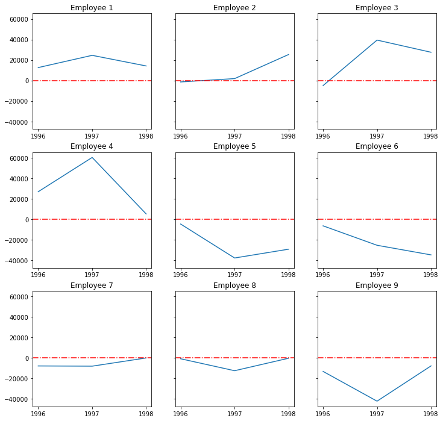

```python
# creating grid of line charts
fig, axs = plt.subplots(3, 3, sharey = True, figsize = (12, 12))

axs[0,0].plot(salesPerYear.loc[1, "totRevDiff"])
axs[0,0].set_title("Employee 1")

axs[0,1].plot(salesPerYear.loc[2, "totRevDiff"])
axs[0,1].set_title("Employee 2")

axs[0,2].plot(salesPerYear.loc[3, "totRevDiff"])
axs[0,2].set_title("Employee 3")

axs[1,0].plot(salesPerYear.loc[4, "totRevDiff"])
axs[1,0].set_title("Employee 4")

axs[1,1].plot(salesPerYear.loc[5, "totRevDiff"])
axs[1,1].set_title("Employee 5")

axs[1,2].plot(salesPerYear.loc[6, "totRevDiff"])
axs[1,2].set_title("Employee 6")

axs[2,0].plot(salesPerYear.loc[7, "totRevDiff"])
axs[2,0].set_title("Employee 7")

axs[2,1].plot(salesPerYear.loc[8, "totRevDiff"])
axs[2,1].set_title("Employee 8")

axs[2,2].plot(salesPerYear.loc[9, "totRevDiff"])
axs[2,2].set_title("Employee 9")

for ax in axs.flat:
    ax.axhline(y = 0, color = "red", linestyle = "dashdot")
```

From this visualization, we can identify that employees 1 and 4 are consistently overperforming, while employees 5, 6, and 9 and consistently underperforming. We can also identify that employee 6 is progressively getting worse over time.

Shifting gears, we are going to look into regional sales. We will merge in information about customers, regions, and territories with our Orders dataframe. Each employee only operates within a single region, so we want to see how that is going, and how evenly sales are split up among regions and employees.

```python
# Read in Customers table
cust = pd.read_sql_query('SELECT CustomerID, CompanyName FROM Customers;', con)

# Read in Territories table
terr = pd.read_sql_query('SELECT TerritoryID, RegionID FROM Territories;', con)
# Read in EmployeeTerritories table
empTerr = pd.read_sql_query('SELECT * FROM EmployeeTerritories;', con)
# Read in Regions table
region = pd.read_sql_query('SELECT * FROM Regions;', con)

# merge on Territory ID to link the regions/employees for each territory
terr = terr.merge(region, on = "RegionID")
terr = terr.merge(empTerr, on = "TerritoryID")

# Merge in customers table with orders
orders2 = orders2.merge(cust, on = "CustomerID")
# Merge in territories table with orders
orders2 = orders2.merge(terr, on = "EmployeeID")

# Show revenue by Region w/corresponding employee
orders2.groupby(["RegionID", "EmployeeID"])["Revenue"].sum()
```

```
RegionID  EmployeeID
1         1              384215.18
          2             1165764.32
          4              698672.61
          5              481546.03
2         6              369565.70
          7             1245682.20
3         8              507449.08
          9              541156.42
4         3              811251.28
Name: Revenue, dtype: float64
```

It is interesting that all employees except number 3 share a region. Employee 3 (Janet) has region 4 (the South) all to herself, for better or worse.

And in Region 2, for some reason Employee 7 is getting almost all the sales, while Employee 6 flounders, as we noted earlier. This is happening to a lesser extent in Region 1, with Employee 2 outselling the others there.

We will look and see how different employees are using their ability to discount the price. Here we will calculate the total amount of discounts given by each employee:

```python
# Add up total amount discounted off full price by each employee
orders2.groupby(["EmployeeID"])["DiscountAmt"].sum()
```

```
EmployeeID
1     20072.24
2     78480.50
3     40953.88
4     51889.74
5     47428.22
6     21424.85
7    167277.70
8     25755.04
9     39591.58
Name: DiscountAmt, dtype: float64
```

This is quite concerning, if accurate. Employee 7 has given out \$167,277.70 in discounts, more than double any other employee. No wonder 7 is getting almost all of the sales in Region 2, while Employee 6 continues to fall behind in sales.

Again, this is happening to a lesser extent in Region 1, with Employee 2 out-discounting and outselling the others there. This is potentially contributing to Employee 1's sales lagging behind others in the region.

We can create a visualization to show how extreme Employee 7's usage of discounts is.

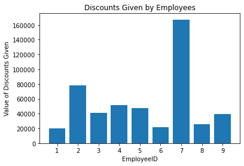

```python
# saving data to be used in graph
discounts = orders2.groupby("EmployeeID")["DiscountAmt"].sum()

# creating bar chart
emps = [x for x in range(1,10)]
plt.bar(x = emps, height = discounts)
plt.xticks(emps)
plt.xlabel("EmployeeID")
plt.ylabel("Value of Discounts Given")
plt.title("Discounts Given by Employees")
plt.show()
plt.close()
```

Employee 7 is giving out a staggering amount of discounts compared to everybody else. The next highest is Employee 2 (who is still well above the rest of the employees), and they have not even given out half the amount of discounts as Employee 7 has.

Time to take a closer look at what products we are selling. We will combine the products, suppliers, and regions tables with our orders dataframe to see how much of which products our employees are selling.

```python
# Read in Products table
prod = pd.read_sql_query('SELECT * FROM Products;', con)
# Read in Suppliers table
supp = pd.read_sql_query('SELECT SupplierID, CompanyName FROM Suppliers;', con)
# Read in Regions table
categories = pd.read_sql_query('SELECT CategoryID, CategoryName FROM Categories;', con)

# merge the three
prod = prod.merge(supp, on = "SupplierID")
prod = prod.merge(categories, on = "CategoryID")

# change ProductID to a string data type
prod = prod.astype({"ProductID": str}, errors='raise')

# merge into our orders table
orders2 = orders2.merge(prod, on = "ProductID")
```

```python
# Set some printing options to see more of the pandas object
pd.set_option('display.max_rows', 100)
pd.set_option('display.max_columns', 50)
```

```python
# Add up revenue by product for each employee
productsSold = orders2.groupby(["EmployeeID", "ProductName"])["Revenue"].sum()
```

We will look at the total revenue by product and by employee. Let's just see what the top revenue-producing products are.

```python
productsSold.sort_values(ascending = False).head(20)
```

```
EmployeeID  ProductName
2           CÃ´te de Blaye               176334.20
7           CÃ´te de Blaye               166953.60
            ThÃ¼ringer Rostbratwurst     146691.10
2           ThÃ¼ringer Rostbratwurst     110915.84
9           CÃ´te de Blaye               102369.75
3           CÃ´te de Blaye               102238.00
9           Raclette Courdavault          99410.85
7           Raclette Courdavault          91366.00
4           CÃ´te de Blaye                88298.85
7           RÃ¶ssle Sauerkraut            63747.20
3           Gnocchi di nonna Alice        55662.40
5           Raclette Courdavault          53091.50
2           Tarte au sucre                51751.00
7           Queso Manchego La Pastora     51148.00
3           ThÃ¼ringer Rostbratwurst      49268.40
1           CÃ´te de Blaye                47140.16
2           Raclette Courdavault          45969.00
7           Tarte au sucre                44616.50
3           Camembert Pierrot             44438.00
5           CÃ´te de Blaye                44268.00
Name: Revenue, dtype: float64
```

The top revenue producing items appear to be a French wine, a German bratwurst, and a Swiss cheese. We can investigate which employees sell the most of the best performing product - the French wine "CÃ´te de Blaye".

```python
orders2.loc[orders2["ProductName"] == "CÃ´te de Blaye"].groupby("EmployeeID").sum()["Quantity"]
```

```
EmployeeID
1    190
2    693
3    412
4    390
5    280
7    990
9    399
Name: Quantity, dtype: int64
```

We can see that employee 7 has sold the most units of this product by a pretty wide margin. Conversely, we can see that employees 6 and 8 have sold zero units of this high-selling product.

We can also investigate which category of products are best at generating revenue.

```python
orders2.groupby("CategoryName").sum().sort_values("Revenue", ascending = False)["Revenue"]
```

```
CategoryName
Beverages         1317872.96
Dairy Products    1215757.45
Meat/Poultry       877324.65
Confections        781451.75
Seafood            587185.00
Condiments         514461.79
Produce            469821.18
Grains/Cereals     441428.04
Name: Revenue, dtype: float64
```

Beverages and Dairy seem to be the best-selling product types for this company. Let us investigate which employees generate the most revenue for these product types. First - Beverages.

```python
orders2.loc[orders2["CategoryName"] == "Beverages"].groupby("EmployeeID").sum() \
.sort_values("Revenue", ascending = False)["Revenue"]
```

```
EmployeeID
2    281737.75
7    279638.30
3    179029.60
4    150924.63
9    137497.85
1     93198.72
5     77003.71
8     71591.40
6     47251.00
Name: Revenue, dtype: float64
```

Employees 2 and 7 seem to dominate the sales of Beverages, while employees 5, 8, and 6 are left far behind.

Next - Dairy Products.

```python
orders2.loc[orders2["CategoryName"] == "Dairy Products"].groupby("EmployeeID").sum() \
.sort_values("Revenue", ascending = False)["Revenue"]
```

```
EmployeeID
7    276218.60
2    166687.85
5    153563.34
9    147707.84
3    129283.36
4    100649.40
6     85195.20
8     84405.88
1     72045.98
Name: Revenue, dtype: float64
```

It appears that employee 7 has sold far more Dairy Products than anyone else.

As a result of all of our analysis, we have identified a main area of strength for each employee:

Strengths:

1. Most consistent based on being +/- \$200 from overall revenue per order each year.  
   2. Has steadily improved each year in revenue per order and total revenue. Good, consistent improvement.
2. Most improvement year over year (revenue per order metric).
3. Most overall orders at 156, highest overall revenue at \$232k.  
   5. Among the top sellers of Dairy products, one of the company’s best selling product categories.
4. Along with employee 1, gave out very low discounts, even though it must have cost them a lot of sales to the other employee in the region.  
   7. Has sold the most units of the best-selling product (French wine “CÃ´te de Blaye”).
5. Doing a good job splitting up sales evenly in Region with Employee 9.
6. Highest revenue per order at \$1798.

We also identified an area each employee could improve.  
Improves: